# Comparisons of IMDb Movie Review Attributes

### Saunders Cox

What are the relationships between review sentiment, review length, and rating of reviews?

We know that ratings are an indicator of someone's perception of a movie, but can we make any assumption about the review's length or sentiment depending on the rating?

We know that the reviews have hard defined ratings and review length; however the review sentiment is fairly subjective given that we are using a predefined set of positive and negative words to estimate the net sentiment (positive words - negative words).

The following movies were analyzed:

1. Silence of the Lambs
2. The Shining
3. La La Land
4. Moulin Rouge
5. Shrek
6. Finding Nemo
7. Dark Skies
8. Paprika
9. The Conjuring 2
10. Fight Club

We have mystery, horror, drama, comedy, family, and thriller genres to gather a diverse set of language. It should seem that given:

- Low rating -> Mix of low and high length reviews
  - I expect a reviewer to not give a movie they disliked much thought, or perhaps they had much to complain about.
- Low rating -> Low net sentiment
  - I expect the negative language to overpower the positive language; however there may be some positive language that is simply a counterpoint to what the movie could have been.
- High rating -> Generally higher length reviews
  - I expect praise to translate into longer discussion of the movie.
- High rating -> High net sentiment
  - I expect the higher rated reviews to translate into mostly positive sentiment. However for the horror films, the negative language may be stronger and cancel out some of the positive language. This would produce some misinterpretation of the reviews, but I would expect on average, the positive sentiment is greater.

## Q 1.1 Rating vs Length

As mentioned, the rating of a review can be measured on a very narrow scale in comparison to the other measuring methods. What trend might we expect to see when we compare the most quantitative values: rating on a scale of 1-10 and length of the review? It would make sense that people would have more to say the more polarized their feelings are towards the movie. Let's see if that holds up.

## Q 1.2 Boxplot of Review Text Length to Rating

```python
import pandas as pd
import matplotlib.pyplot as plt
import re

# First, we'll import our movie review data from the previous assignment
data = pd.read_csv("movies.csv")
titles = ['No.', 'Title', 'Rating', 'User', 'Date', 'Review', 'URL']
data.columns = titles

# We'll also measure the character length of each review
data['Length'] = [len(data.iloc[i,5]) for i in range(0, data.shape[0])]
data['LengthZ'] = (data.Length - data.Length.mean()) / data.Length.std()
```

```python
# Let's peek into a sample of the data we're working with
data.iloc[1000]
```

```
No.                                                     1001
Title                                                Paprika
Rating                                                     8
User                                            brchthethird
Date                                            1 March 2015
Review     I sure picked a doozy of a film for my second ...
URL        https://www.imdb.com/title/tt0851578/reviews/_...
Length                                                  1987
LengthZ                                             0.526691
Name: 1000, dtype: object
```

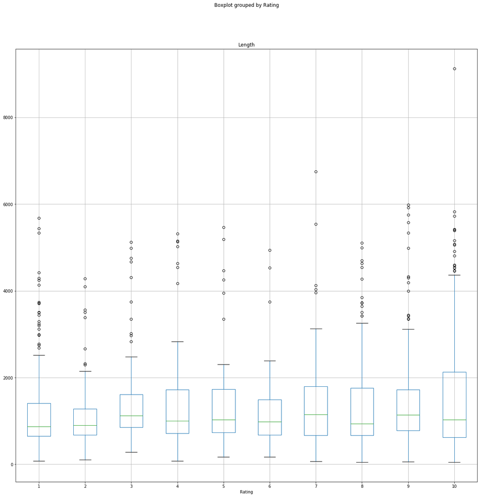

```python
# Now we can explore the review length distributions of each rating
boxplot = data.boxplot(column=['Length'], by='Rating', layout=(1, 1), figsize=(20, 20))
```

## Q 1.3 Rating vs Length Conclusion

It appears that the lower quartiles hover around the same area. These are reviews that had little effort; the users probably wanted to get their star rating submitted and be done with the review.

On the other hand, we can see that the upper quartiles vary much more greatly. There is no clear trend for the lower ratings, but on the ratings for 7 and up, we can assume that users generally had more to discuss. This seems to support one of our hypotheses--that higher rating translates to longer reviews.

There seems to be more outliers on either end of the spectrum, but that is simply because in the figure following this cell, it is shown that there are far more reviewers that give 1 star and 10 star reviews.

```python
# With this same data, we form a visualization for our ratings distribution
ratingList = [[] for i in range(11)]

for n in range(1,11):
    ratingList[n] = [data.iloc[i] for i in range(0, data.shape[0]) if data.iloc[i].Rating==n]

ratingCount = [len(i) for i in ratingList]
ratingCount
```

```
[0, 277, 90, 70, 70, 55, 51, 87, 136, 145, 350]
```

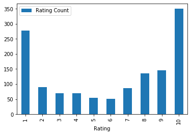

```python
df = pd.DataFrame({'Rating':[i for i in range(1, 11)], 'Rating Count':[ratingCount[i] for i in range(1, 11)]})
df
df.plot.bar(x='Rating', y='Rating Count')
```

### Q 1.3 Cont.

As seen above, there is a clearly defined distribution in the amount of ratings per each rating. People tend to be polarized in their responses. As was expected, people tend to review for movies they love more than they hate, but rarely do people decide to rate a movie if they feel it was middle of the park. Perhaps this could be insight for directors to try and go all the way or just make a joke of themselves e.g. "The Room".

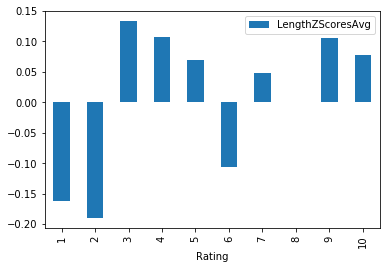

```python
LengthZScores = []

for s in range(1, 11):
    LengthZScores.append(sum([ratingList[s][i].LengthZ for i in range(0, len(ratingList[s]))]) / len(ratingList[s]))

df['LengthZScoresAvg'] = LengthZScores
df.plot.bar(x='Rating', y='LengthZScoresAvg')
```

### Q 1.3 Cont.

Although there was a clear correlation to reviewer count to ratings, there was no apparent correlation to the average z-score review length per rating across the board.

However, we can guess that people that give low scores have less to say on average. While the smaller crowd who gives a movie a rating of 3 to 5 have a bit more reasoning on their rating. And for some reason, people who give a 6 generally won't say as much. And people who give a 7 to a 10 will write a lengthy review with the odd exception of people who give an 8.

This information is important to reveal upfront to better understand how the rest of our data will be analyzed. The gist of this precursor is to understand that most reviews will be polarized, and that the average length of each review has a strong correlation with rating only on polarized ratings i.e. movies with the lowest ratings have lower length reviews, while movies with the highest ratings have higher length reviews, and movies with ratings towards the middle have no clear correlation on review length.

## Q 2.1 Rating vs. Net Sentiment

Now we have a more abstract measurement of sentiment. It might seem obvious to make an assumption that rating will have a positive correlation to what we will refer to as "net sentiment". But is that the case? Remember that our movie selection is diverse, so we'll have a good mix of all reviews, so if we find some oddities in our visualizations, we can theorize what's happening.

Let's first define how we are measuring sentiment. We will count how many positive words, negative words, and total words we have in each review and use them to analyze our data.

## Q 2.2 Expanding Our Data

To evaluate sentiment we'll need to dig deeper to create more data from our data. We'll begin by storing all the positive words and negative words and the amount of each to the main dataframe.

```python
positives = set(open('positive.txt').read().split())
negatives = set(open('negative.txt').read().split())


data['Words'] = [re.sub("[^\w]", " ", data.Review[i]).split() for i in range(data.shape[0])]
# data['WordCount'] = [len(data.Words[i]) for i in range(data.shape[0])]

data['Positives'] = [([w for w in data.Words[r] if w in positives]) for r in range(0, data.shape[0])]
data['PosCount'] = [len(data.Positives[i]) for i in range(data.shape[0])]

data['Negatives'] = [([w for w in data.Words[r] if w in negatives]) for r in range(0, data.shape[0])]
data['NegCount'] = [len(data.Negatives[i]) for i in range(data.shape[0])]

data['NetSentiment'] = [(data.iloc[i].PosCount - data.iloc[i].NegCount) for i in range(0, data.shape[0])]

data
```

|  | No. | Title | Rating | User | Date | Review | URL | Length | LengthZ | Words | Positives | PosCount | Negatives | NegCount | NetSentiment |
| --- | --- | --- | --- | --- | --- | --- | --- | --- | --- | --- | --- | --- | --- | --- | --- |
| 0 | 1 | Silence of the Lambs | 9 | Aaron_Kyle | 8 June 2019 | The Silence of the Lambs is a timeless classic... | https://www.imdb.com/title/tt0102926/reviews/_... | 1304 | -0.067567 | [The, Silence, of, the, Lambs, is, a, timeless... | [classic, adequate, entertaining, fun, genius,... | 19 | [least, disturbingly, horror, horror, blood] | 5 | 14 |
| 1 | 2 | Silence of the Lambs | 10 | MaxBorg89 | 22 October 2005 | The Silence of the Lambs runs two hours.Anthon... | https://www.imdb.com/title/tt0102926/reviews/_... | 1335 | -0.040595 | [The, Silence, of, the, Lambs, runs, two, hour... | [even, intelligent, charismatic, good, taste, ... | 17 | [little, impossible, brutal, killer, revolting... | 7 | 10 |
| 2 | 3 | Silence of the Lambs | 10 | ccthemovieman-1 | 17 January 2007 | I'll never forget my first viewing of this mov... | https://www.imdb.com/title/tt0102926/reviews/_... | 1869 | 0.424023 | [I, ll, never, forget, my, first, viewing, of,... | [will, fondly, reason, well, super, entertaini... | 18 | [killer, sick, profane, unpleasant, infamous, ... | 16 | 2 |
| 3 | 4 | Silence of the Lambs | 10 | Smells_Like_Cheese | 28 August 2004 | I've seen way too many thrillers. You name it:... | https://www.imdb.com/title/tt0102926/reviews/_... | 578 | -0.699238 | [I, ve, seen, way, too, many, thrillers, You, ... | [friend, naturally, open, glad, friend, right,... | 11 | [crazy, down] | 2 | 9 |
| 4 | 5 | Silence of the Lambs | 9 | FrenchEddieFelson | 10 August 2019 | I just saw, for the second or third time, this... | https://www.imdb.com/title/tt0102926/reviews/_... | 1420 | 0.033361 | [I, just, saw, for, the, second, or, third, ti... | [just, masterpiece, winners, excellent, skillf... | 16 | [obviously, terror] | 2 | 14 |
| 5 | 6 | Silence of the Lambs | 10 | davideo-2 | 16 November 2005 | STAR RATING: ***** The Works **** Just Misses ... | https://www.imdb.com/title/tt0102926/reviews/_... | 2428 | 0.910392 | [STAR, RATING, The, Works, Just, Misses, the, ... | [prominent, well, help, effective, modern, app... | 24 | [notorious, killer, killer, against, inevitabl... | 14 | 10 |
| 6 | 7 | Silence of the Lambs | 10 | crisp_morning_2004 | 11 August 2006 | It is a creepy and taken-by-storm experience w... | https://www.imdb.com/title/tt0102926/reviews/_... | 2462 | 0.939975 | [It, is, a, creepy, and, taken, by, storm, exp... | [brilliantly, unforgettable, intelligence, gra... | 21 | [ominous, provocative, hard, odd, cruelty, ins... | 30 | -9 |
| 7 | 8 | Silence of the Lambs | 10 | notoriousCASK | 1 August 2017 | The Silence of the Lambs is a masterpiece you ... | https://www.imdb.com/title/tt0102926/reviews/_... | 4456 | 2.674895 | [The, Silence, of, the, Lambs, is, a, masterpi... | [masterpiece, smooth, top, bonus, exquisite, s... | 65 | [horror, crime, violent, murder, killer, dread... | 21 | 44 |
| 8 | 9 | Silence of the Lambs | 10 | nickpal1983 | 17 July 2005 | There is little doubt that the most memorable ... | https://www.imdb.com/title/tt0102926/reviews/_... | 1352 | -0.025803 | [There, is, little, doubt, that, the, most, me... | [memorable, effective, especially, memorable, ... | 17 | [little, doubt, incomparable, evil, dying, sto... | 13 | 4 |
| 9 | 10 | Silence of the Lambs | 7 | mash_31 | 20 August 2019 | This movie has great directing, alright cinema... | https://www.imdb.com/title/tt0102926/reviews/_... | 537 | -0.734911 | [This, movie, has, great, directing, alright, ... | [great, amazing, solid, brilliant, well, enjoy... | 10 | [slow] | 1 | 9 |
| 10 | 11 | Silence of the Lambs | 10 | ivo-cobra8 | 25 May 2016 | The Silence of the Lambs (1991) is a classic p... | https://www.imdb.com/title/tt0102926/reviews/_... | 4363 | 2.593978 | [The, Silence, of, the, Lambs, 1991, is, a, cl... | [classic, brilliant, masterpiece, well, right,... | 46 | [disappointed, death, disappointed, incompeten... | 20 | 26 |
| 11 | 12 | Silence of the Lambs | 8 | Theo Robertson | 30 October 2005 | It's impossible to comment on SILENCE OF THE L... | https://www.imdb.com/title/tt0102926/reviews/_... | 2969 | 1.381100 | [It, s, impossible, to, comment, on, SILENCE, ... | [popular, myriad, success, effective, striking... | 22 | [impossible, mere, down, dim, moody, phobia, a... | 19 | 3 |
| 12 | 13 | Silence of the Lambs | 6 | ruffinelli_ro | 17 March 2009 | It is really difficult for me to understand wh... | https://www.imdb.com/title/tt0102926/reviews/_... | 650 | -0.636593 | [It, is, really, difficult, for, me, to, under... | [honestly, even, terrific, just] | 4 | [difficult, horror, uncomfortable, little] | 4 | 0 |
| 13 | 14 | Silence of the Lambs | 7 | mickey-86073 | 13 July 2019 | The story was really good but production and d... | https://www.imdb.com/title/tt0102926/reviews/_... | 70 | -1.141233 | [The, story, was, really, good, but, productio... | [good] | 1 | [hideous] | 1 | 0 |
| 14 | 15 | Silence of the Lambs | 10 | nobbytatoes | 27 October 2005 | Agent Clarice Starling is a training FBI agent... | https://www.imdb.com/title/tt0102926/reviews/_... | 1820 | 0.381389 | [Agent, Clarice, Starling, is, a, training, FB... | [hope, intelligent, help, intrigue, friendship... | 14 | [insanely, criminal, strange, dark, twisted, d... | 13 | 1 |
| 15 | 16 | Silence of the Lambs | 9 | murtaza_mma | 24 April 2009 | Silence of the Lambs is a quintessence of a pr... | https://www.imdb.com/title/tt0102926/reviews/_... | 1723 | 0.296993 | [Silence, of, the, Lambs, is, a, quintessence,... | [profound, vivid, subtle, brilliance, acclaim,... | 19 | [nebulous, unqualified, envy, devoid, deviousl... | 14 | 5 |
| 16 | 17 | Silence of the Lambs | 10 | AgentDice | 8 October 2013 | Once upon a crime, Hannibal Lecter was a manip... | https://www.imdb.com/title/tt0102926/reviews/_... | 1518 | 0.118628 | [Once, upon, a, crime, Hannibal, Lecter, was, ... | [hero, astute, good, haven, perfectly, better,... | 18 | [crime, manipulative, killer, horror, shocking... | 16 | 2 |
| 17 | 18 | Silence of the Lambs | 1 | Brian-268 | 20 May 2000 | That the film has its moments cannot be denied... | https://www.imdb.com/title/tt0102926/reviews/_... | 2992 | 1.401112 | [That, the, film, has, its, moments, cannot, b... | [top, enjoyable, appeal, erudite, free, spirit... | 23 | [slightly, diabolical, relentlessly, goading, ... | 35 | -12 |
| 18 | 19 | Silence of the Lambs | 2 | saffron-3 | 6 October 1999 | This film has a silly premise, a lousy script,... | https://www.imdb.com/title/tt0102926/reviews/_... | 1719 | 0.293512 | [This, film, has, a, silly, premise, a, lousy,... | [plausibility, novel, apt, kind, just, good, p... | 7 | [silly, lousy, dreadful, pretentious, killer, ... | 20 | -13 |
| 19 | 20 | Silence of the Lambs | 9 | jtkrings | 22 February 2016 | Silence of the Lambs (1991) follows the story ... | https://www.imdb.com/title/tt0102926/reviews/_... | 3354 | 1.716077 | [Silence, of, the, Lambs, 1991, follows, the, ... | [ambitious, help, excellent, eager, poised, in... | 30 | [killer, infamous, killer, killer, painfully, ... | 26 | 4 |
| 20 | 21 | Silence of the Lambs | 9 | joyous-sunshine | 8 July 2015 | "The Silence of the Lambs" deserves its recogn... | https://www.imdb.com/title/tt0102926/reviews/_... | 2239 | 0.745949 | [The, Silence, of, the, Lambs, deserves, its, ... | [recognition, classic, brilliantly, articulate... | 21 | [extremely, extreme, close, antagonist, bad, i... | 7 | 14 |
| 21 | 22 | Silence of the Lambs | 10 | manikas8 | 7 November 2005 | One of the best movies of the 90's and one of ... | https://www.imdb.com/title/tt0102926/reviews/_... | 751 | -0.548716 | [One, of, the, best, movies, of, the, 90, s, a... | [perfect, kind, hero, majestic, real, perfect,... | 7 | [cannibal, killer, fight] | 3 | 4 |
| 22 | 23 | Silence of the Lambs | 3 | ebtsamryad | 6 August 2019 | It was nothing .. silence of the lambs is such... | https://www.imdb.com/title/tt0102926/reviews/_... | 2480 | 0.955636 | [It, was, nothing, silence, of, the, lambs, is... | [good, will, calm, smart, even, okay, even, ev... | 18 | [damn, shock, annoyed, criminal, scary, cannib... | 21 | -3 |
| 23 | 24 | Silence of the Lambs | 1 | horror69 | 19 April 2002 | After hearing how great this film is i had to ... | https://www.imdb.com/title/tt0102926/reviews/_... | 701 | -0.592219 | [After, hearing, how, great, this, film, is, i... | [great, will, reason, worth, thrill] | 5 | [boring, dumb] | 2 | 3 |
| 24 | 25 | Silence of the Lambs | 9 | DrEbert | 28 December 2007 | The late Gene Siskel hated "The Silence of the... | https://www.imdb.com/title/tt0102926/reviews/_... | 5579 | 3.651983 | [The, late, Gene, Siskel, hated, The, Silence,... | [originality, stars, originality, brilliant, h... | 51 | [gruesome, distasteful, lacking, fear, killer,... | 50 | 1 |
| 25 | 26 | Silence of the Lambs | 1 | NEFARlOUS | 25 March 1999 | Having read both the Prequel (Manhunter) and S... | https://www.imdb.com/title/tt0102926/reviews/_... | 1694 | 0.271761 | [Having, read, both, the, Prequel, Manhunter, ... | [better, calm, believable, real, veritable, wi... | 16 | [danger, mere, insanity, monster, dungeon, evi... | 8 | 8 |
| 26 | 27 | Silence of the Lambs | 9 | Xophianic | 19 April 2017 | Finally, I saw this movie for the first time y... | https://www.imdb.com/title/tt0102926/reviews/_... | 2116 | 0.638930 | [Finally, I, saw, this, movie, for, the, first... | [just, great, learned, brilliant, polite, inte... | 20 | [trying, down, killer, killer, dangerous, dist... | 16 | 4 |
| 27 | 28 | Silence of the Lambs | 4 | marioncaspa | 29 October 2016 | This review contains spoilers, for a spoiler-f... | https://www.imdb.com/title/tt0102926/reviews/_... | 2500 | 0.973037 | [This, review, contains, spoilers, for, a, spo... | [free, good, great, security, acclaimed, just,... | 23 | [ridiculously, unrealistic, stupid, stupid, wr... | 24 | -1 |
| 28 | 29 | Silence of the Lambs | 10 | mjw2305 | 2 February 2005 | Silence of the Lambs was the birthplace of Ant... | https://www.imdb.com/title/tt0102926/reviews/_... | 1191 | -0.165885 | [Silence, of, the, Lambs, was, the, birthplace... | [intelligent, vulnerable, gain, brilliant, gai... | 14 | [killer, dangerous, dark, gloomy, horror] | 5 | 9 |
| 29 | 30 | Silence of the Lambs | 10 | Derek237 | 16 March 2003 | The Silence of The Lambs explores the life and... | https://www.imdb.com/title/tt0102926/reviews/_... | 963 | -0.364261 | [The, Silence, of, The, Lambs, explores, the, ... | [deal, interesting, deal, just, highlight, del... | 8 | [unusual, obviously, violent, terrible, scariest] | 5 | 3 |
| ... | ... | ... | ... | ... | ... | ... | ... | ... | ... | ... | ... | ... | ... | ... | ... |
| 1301 | 1302 | Fight Club | 4 | Pumpkin_Man | 10 June 2015 | Last night was the very first time I have ever... | https://www.imdb.com/title/tt0137523/reviews/_... | 1158 | -0.194597 | [Last, night, was, the, very, first, time, I, ... | [friends, decent, funny, stars, support, just,... | 8 | [trying, bad, down, fight, weird, twist, miser... | 8 | 0 |
| 1302 | 1303 | Fight Club | 10 | DerBarenJude | 26 November 2004 | Fight Club's simple title, aptly chosen by the... | https://www.imdb.com/title/tt0137523/reviews/_... | 1304 | -0.067567 | [Fight, Club, s, simple, title, aptly, chosen,... | [simple, aptly, relevant, better, novel, will,... | 14 | [extremely, scathing, fight, destruction, shock] | 5 | 9 |
| 1303 | 1304 | Fight Club | 10 | jbltk | 2 October 2004 | The people that don't like this generally fall... | https://www.imdb.com/title/tt0137523/reviews/_... | 1935 | 0.481448 | [The, people, that, don, t, like, this, genera... | [content, stylish, fun, modern, ultimate, true... | 10 | [shallow, against, down, incapable, unable, di... | 17 | -7 |
| 1304 | 1305 | Fight Club | 10 | swiftyl | 6 October 1999 | The Fight Club is a movie that makes you want ... | https://www.imdb.com/title/tt0137523/reviews/_... | 694 | -0.598310 | [The, Fight, Club, is, a, movie, that, makes, ... | [friends, good, good, beautifully, clean] | 5 | [punch, extreme, tension, wicked, endless] | 5 | 0 |
| 1305 | 1306 | Fight Club | 10 | afroman-3 | 4 October 1999 | You would only do a flick like Fight Club if y... | https://www.imdb.com/title/tt0137523/reviews/_... | 551 | -0.722730 | [You, would, only, do, a, flick, like, Fight, ... | [truly, genius, truly, amazing, funny] | 5 | [disregard, critics, dark, dark, serious] | 5 | 0 |
| 1306 | 1307 | Fight Club | 1 | Mikey-99 | 18 October 1999 | This is the first film I have seen in which th... | https://www.imdb.com/title/tt0137523/reviews/_... | 422 | -0.834969 | [This, is, the, first, film, I, have, seen, in... | [good, even, interest, even, revelation] | 5 | [twist, utterly, twist, twist, ridiculous, idi... | 7 | -2 |
| 1307 | 1308 | Fight Club | 2 | TXastorian | 21 May 2004 | Ed Norton character: "I don't know. I'm just n... | https://www.imdb.com/title/tt0137523/reviews/_... | 1407 | 0.022050 | [Ed, Norton, character, I, don, t, know, I, m,... | [just, content, benefit, happy, just, live, co... | 13 | [shallow, poor, unfulfilled, ridiculous, plagu... | 8 | 5 |
| 1308 | 1309 | Fight Club | 1 | morpheus-108 | 3 June 2000 | The movie is about an ordinary guy, who leads ... | https://www.imdb.com/title/tt0137523/reviews/_... | 1468 | 0.075125 | [The, movie, is, about, an, ordinary, guy, who... | [above, personality, personality, even, establ... | 9 | [drab, trying, idiot, low, destruction, chaos,... | 20 | -11 |
| 1309 | 1310 | Fight Club | 2 | elliotff | 3 August 2004 | I cannot believe the number of rabid fans this... | https://www.imdb.com/title/tt0137523/reviews/_... | 796 | -0.509562 | [I, cannot, believe, the, number, of, rabid, f... | [indulgent, amusing, real] | 3 | [down, pity, tawdry, deep, need] | 5 | -2 |
| 1310 | 1311 | Fight Club | 1 | ArdentViewer | 5 February 2000 | I ordinarily don't take the time to comment on... | https://www.imdb.com/title/tt0137523/reviews/_... | 694 | -0.598310 | [I, ordinarily, don, t, take, the, time, to, c... | [just] | 1 | [worst, gratuitous, blood, waste] | 4 | -3 |
| 1311 | 1312 | Fight Club | 2 | Oggz | 3 June 2006 | ...in which pretty much the only aspect that d... | https://www.imdb.com/title/tt0137523/reviews/_... | 1097 | -0.247671 | [in, which, pretty, much, the, only, aspect, t... | [pretty, kind, haven, good, good, just, good, ... | 8 | [lukewarm, horribly, obviously, lying, deluded... | 11 | -3 |
| 1312 | 1313 | Fight Club | 3 | jay4stein79-1 | 16 April 2006 | I can't go on. No, I will go on. Fight Club re... | https://www.imdb.com/title/tt0137523/reviews/_... | 2458 | 0.936494 | [I, can, t, go, on, No, I, will, go, on, Fight... | [will, intelligence, wide, elevated, masterpie... | 25 | [worst, subversion, pointless, wrong, trying, ... | 22 | 3 |
| 1313 | 1314 | Fight Club | 1 | Sailor-21 | 5 November 1999 | This is the worst piece of trash I've seen in ... | https://www.imdb.com/title/tt0137523/reviews/_... | 976 | -0.352950 | [This, is, the, worst, piece, of, trash, I, ve... | [talented, even, sane, intelligent, redeeming,... | 6 | [worst, hypocrisy, pain, tiresome, tiresome, i... | 9 | -3 |
| 1314 | 1315 | Fight Club | 1 | preslopsky | 4 January 2002 | Let me just get this out of the way right off ... | https://www.imdb.com/title/tt0137523/reviews/_... | 1493 | 0.096877 | [Let, me, just, get, this, out, of, the, way, ... | [just, right, friends, friends, clever, clever... | 20 | [divided, terrorism, chaos, complex, little, l... | 7 | 13 |
| 1315 | 1316 | Fight Club | 6 | MartinHafer | 11 September 2008 | Edward Norton and Brad Pitt form a very strang... | https://www.imdb.com/title/tt0137523/reviews/_... | 2225 | 0.733768 | [Edward, Norton, and, Brad, Pitt, form, a, ver... | [strong, friendship, joy, brains, interesting,... | 17 | [strange, odd, bizarre, weird, idiots, little,... | 17 | 0 |
| 1316 | 1317 | Fight Club | 3 | rams_lakers | 29 September 2004 | Who needs this movie? I sure don't. Looks like... | https://www.imdb.com/title/tt0137523/reviews/_... | 1611 | 0.199545 | [Who, needs, this, movie, I, sure, don, t, Loo... | [sure, love, perfect, taste, kind, free, fanta... | 19 | [hell, misunderstood, need, angry, need, disgu... | 12 | 7 |
| 1317 | 1318 | Fight Club | 2 | manlover | 15 July 2000 | This movie is not that good. After seeing this... | https://www.imdb.com/title/tt0137523/reviews/_... | 1111 | -0.235490 | [This, movie, is, not, that, good, After, seei... | [good, will, worth, reason, sense, fairly, eve... | 9 | [bad, awful, impossible, bad, mean, bad, fight... | 12 | -3 |
| 1318 | 1319 | Fight Club | 3 | wperkins | 1 May 2000 | ...signifying nothing." Nah, it wasn't that b... | https://www.imdb.com/title/tt0137523/reviews/_... | 1160 | -0.192857 | [signifying, nothing, Nah, it, wasn, t, that, ... | [just, terrifically, great, modern, right, sol... | 9 | [bad, disappointing, hollow, problem, senseles... | 9 | 0 |
| 1319 | 1320 | Fight Club | 4 | Tallgent | 5 March 2000 | Arguably, nihilism in films is best personifie... | https://www.imdb.com/title/tt0137523/reviews/_... | 5024 | 3.169094 | [Arguably, nihilism, in, films, is, best, pers... | [classic, intriguing, live, novel, successful,... | 42 | [bleak, despairing, less, disappointment, nigh... | 29 | 13 |
| 1320 | 1321 | Fight Club | 2 | JustnNLA | 21 October 1999 | Admittedly, I would have never gone to see Fig... | https://www.imdb.com/title/tt0137523/reviews/_... | 748 | -0.551326 | [Admittedly, I, would, have, never, gone, to, ... | [even, just, honestly] | 3 | [violent, gross, violent, violent, gratuitous,... | 7 | -4 |
| 1321 | 1322 | Fight Club | 1 | iamsethh | 4 November 2000 | This movie is a well crafted, exciting, and ul... | https://www.imdb.com/title/tt0137523/reviews/_... | 620 | -0.662695 | [This, movie, is, a, well, crafted, exciting, ... | [well, exciting, ultimately, will, will] | 5 | [thoughtless, propaganda, slaves, against, pro... | 6 | -1 |
| 1322 | 1323 | Fight Club | 1 | toclement | 7 August 2000 | I cannot believe this film is rated so highly.... | https://www.imdb.com/title/tt0137523/reviews/_... | 450 | -0.810607 | [I, cannot, believe, this, film, is, rated, so... | [accolades, interest, advice, friend, amazed] | 5 | [bias, idiotic] | 2 | 3 |
| 1323 | 1324 | Fight Club | 7 | lizziebeth-1 | 15 September 2006 | "How many nihilists does it take to change a l... | https://www.imdb.com/title/tt0137523/reviews/_... | 6750 | 4.670836 | [How, many, nihilists, does, it, take, to, cha... | [light, impressive, novel, welcome, eagerly, j... | 39 | [black, comedy, hard, abyss, brutality, fright... | 67 | -28 |
| 1324 | 1325 | Fight Club | 10 | MovieAddict2016 | 26 December 2004 | The first time I saw "Fight Club" I despised i... | https://www.imdb.com/title/tt0137523/reviews/_... | 2937 | 1.353258 | [The, first, time, I, saw, Fight, Club, I, des... | [realistic, better, just, happy, brilliant, ju... | 28 | [despised, stupid, contradictory, hypocritical... | 28 | 0 |
| 1325 | 1326 | Fight Club | 1 | dlgart | 19 August 2004 | I refuse to give away details of a film. There... | https://www.imdb.com/title/tt0137523/reviews/_... | 1041 | -0.296395 | [I, refuse, to, give, away, details, of, a, fi... | [popularity, even, hug, bright] | 4 | [refuse, obscure, gratuitous, unexpected, twis... | 7 | -3 |
| 1326 | 1327 | Fight Club | 1 | CuriosityKilledShawn | 31 October 2000 | Typically over-directed David Fincher nonsense... | https://www.imdb.com/title/tt0137523/reviews/_... | 2177 | 0.692005 | [Typically, over, directed, David, Fincher, no... | [able, regard, meaningful, fun, beauty, free, ... | 15 | [nonsense, depressing, rubbish, deep, cynical,... | 31 | -16 |
| 1327 | 1328 | Fight Club | 7 | glassorange | 19 April 2002 | "Fight Club" is a very good movie, but it is h... | https://www.imdb.com/title/tt0137523/reviews/_... | 762 | -0.539145 | [Fight, Club, is, a, very, good, movie, but, i... | [good, top, groundbreaking, sensational, geniu... | 11 | [pointlessly, ridiculous, obviously, fell] | 4 | 7 |
| 1328 | 1329 | Fight Club | 1 | kenjha | 9 July 2007 | A man tired of his yuppie condo and dead-end j... | https://www.imdb.com/title/tt0137523/reviews/_... | 717 | -0.578298 | [A, man, tired, of, his, yuppie, condo, and, d... | [just, fun, masterpiece] | 3 | [tired, dead, dilapidated, bloody, lame, twist... | 16 | -13 |
| 1329 | 1330 | Fight Club | 1 | mersault3b | 11 January 2001 | A day after the experience, I am still trying ... | https://www.imdb.com/title/tt0137523/reviews/_... | 2099 | 0.624139 | [A, day, after, the, experience, I, am, still,... | [responsible, magnificent, remarkably, real, i... | 19 | [trying, garbage, gratuitous, excessive, oddly... | 22 | -3 |
| 1330 | 1331 | Fight Club | 1 | garyred-2 | 27 August 2000 | Gratuitous violence and a cheesy made-for-teen... | https://www.imdb.com/title/tt0137523/reviews/_... | 345 | -0.901964 | [Gratuitous, violence, and, a, cheesy, made, f... | [will, love, will, will, will] | 5 | [twist, suspect, naive, dumb] | 4 | 1 |

1331 rows × 15 columns

```python
df.index=df.Rating
df
```

| Rating | Rating | Rating Count | LengthZScoresAvg |
| --- | --- | --- | --- |
| 1 | 1 | 277 | -0.162561 |
| 2 | 2 | 90 | -0.190382 |
| 3 | 3 | 70 | 0.134053 |
| 4 | 4 | 70 | 0.107218 |
| 5 | 5 | 55 | 0.069762 |
| 6 | 6 | 51 | -0.106549 |
| 7 | 7 | 87 | 0.047663 |
| 8 | 8 | 136 | 0.000171 |
| 9 | 9 | 145 | 0.106291 |
| 10 | 10 | 350 | 0.077971 |

### Q 2.2 Cont. Net Sentiment vs Rating

#### (Scatterplot as a Variation of Boxplot)

Now we can use combine some of the data we generated from a sentiment analysis.

First we'll use a partially discrete scatter plot. Although it may seem intuitive to use a bar graph or a histogram for everything when using discrete measurements such as rating, we can more easily visualize multiple dimensions with a scatterplot with varying color and sizes.

If we have a scatter plot with the discrete rating on the X-axis, and the net sentiment on the Y-axis, we can see that the majority of reviews result in a net sentiment between -10 and 10 at rating 1. That range gradually seems to condense but not change too much up to rating 5. And from there onward to rating 10, the net sentiment tends to broaden from -5 to 20.

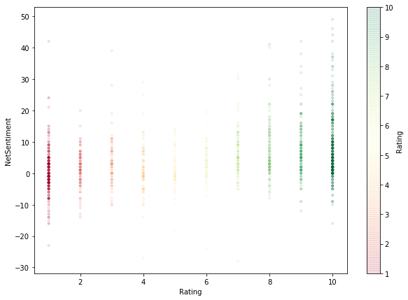

```python
# Scatterplot between length and netsentiment
p = data.plot.scatter(x='Rating', y='NetSentiment', c='Rating', s=10,
               colormap=plt.cm.RdYlGn, figsize=(10, 7), alpha=.1, sharex=False)
```

### Q 2.2 Cont. Negative Vocabulary vs Positive Vocabulary colored by Rating

Next, we'll visualize the rating as a color, and map reviews to a count of total negative vocabulary against total positive vocabulary.

It becomes much easier to see that the green tends towards positive vocabulary and the red tends towards negative vocabulary, but you'll still get both polarized reviews to use both positive and negative language in their reviews.

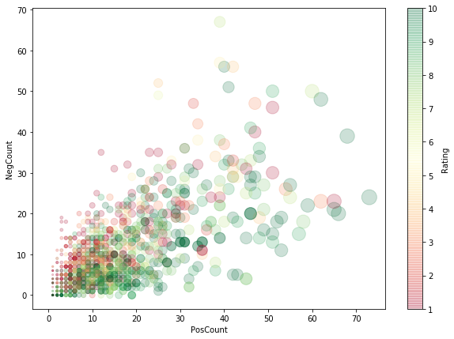

```python
# Scatterplot between r
data['WordCount'] = [len(data.Positives[i]) for i in range(data.shape[0])]

p = data.plot.scatter(x='PosCount', y='NegCount', s=data.WordCount*5, c='Rating',
               colormap=plt.cm.RdYlGn, figsize=(10, 7), alpha=.2, sharex=False)
```

### Q 2.2 Cont. Top 20 Positive and Negative Words

Finally, we can see which words had the biggest effect on representing a review as "positive" or "negative".

```python
posWords = []
for i in range(0, data.shape[0]):
    posWords = posWords+data.Positives[i]

posVocab = list(set(posWords))
len(posVocab)
```

```
1014
```

```python
posVocabTable = pd.DataFrame(posWords, columns=['Word'])
g1 = posVocabTable.groupby('Word')
freqs1 = g1.size()
freqs1 = freqs1.sort_values(ascending=False)
z1 = list(zip(list(freqs1.index), list(freqs1)))
z1[:20]
```

```
[('just', 1088),
 ('good', 852),
 ('will', 605),
 ('even', 592),
 ('great', 590),
 ('well', 589),
 ('love', 392),
 ('better', 327),
 ('real', 280),
 ('right', 214),
 ('dreams', 188),
 ('sense', 187),
 ('interesting', 167),
 ('perfect', 166),
 ('star', 166),
 ('brilliant', 160),
 ('fun', 160),
 ('pretty', 158),
 ('funny', 155),
 ('kind', 148)]
```

```python
negWords = []
for i in range(0, data.shape[0]):
    negWords = negWords+data.Negatives[i]

negVocab = list(set(negWords))
len(negVocab)
```

```
1369
```

```python
negVocabTable = pd.DataFrame(negWords, columns=['Word'])
g2 = negVocabTable.groupby('Word')
freqs2 = g2.size()
freqs2 = freqs2.sort_values(ascending=False)
z2 = list(zip(list(freqs2.index), list(freqs2)))
z2[:20]
```

```
[('horror', 644),
 ('little', 325),
 ('scary', 285),
 ('bad', 274),
 ('down', 207),
 ('killer', 175),
 ('boring', 146),
 ('least', 142),
 ('trying', 131),
 ('wrong', 121),
 ('need', 119),
 ('hard', 114),
 ('less', 95),
 ('worst', 93),
 ('dark', 93),
 ('mean', 91),
 ('evil', 89),
 ('extremely', 88),
 ('comedy', 88),
 ('strange', 87)]
```

## Q 2.3 Conclusion of Net Sentiment vs Rating

From the original scatterplot, we can visualize an ever so slight upward trend towards more positive language as ratings increase. However, it becomes much more clear in the second scatterplot that net sentiment isn't as clear of a visualization as simply mapping negative language against positive language where each point is colored by rating.

It's interesting to see that there is a mix of both positive and negative language, but it is very clear that there is more negative language associated with poor reviews, and more positive language associated with glowing reviews.

And finally we display our top uses of "positive" and "negative" language.

"Good", "Great", "Love", "Perfect", "Brilliant", and "Fun" seem to be good indicators of a glowing review. On the other side, words such as "Just", "Will", and "Even" seem to be very generic words that inflated the positive measurement of the reviews counting for more than 2000 positive words.

For the "negative" language, we have good indicators of a poor review with words such as "Bad", "Boring", and "Worst". On the other hand, we have words that may glorify a movie with sinister themes such as "Horror", "Scary", "Killer", and "Dark", and thus unjustly deflate the praise a reviewer has given to a movie.

In the end, the correlation somewhat supported our hypothesis. If, however, the reviews were for a hotel experience, or a restaurant, it would seem that the correlation of negative and positive words towards negative and positive reviews would be stronger.